# Week 5: Dimensionality reduction

Next, we will do Principal component analysis (PCA) with non scaled data. PCA converts the data to smaller set of variables (principal components) that do not correlate with each other. It is used to bring out patterns in the data.

```r
# perform principal component analysis (with the SVD method)
pca_human <- prcomp(human)
#see the summary of the model
s <- summary(pca_human)
s
```

```
## Importance of components:
##                              PC1      PC2   PC3   PC4   PC5   PC6    PC7
## Standard deviation     1.854e+04 185.5219 25.19 11.45 3.766 1.566 0.1912
## Proportion of Variance 9.999e-01   0.0001  0.00  0.00 0.000 0.000 0.0000
## Cumulative Proportion  9.999e-01   1.0000  1.00  1.00 1.000 1.000 1.0000
##                           PC8
## Standard deviation     0.1591
## Proportion of Variance 0.0000
## Cumulative Proportion  1.0000
```

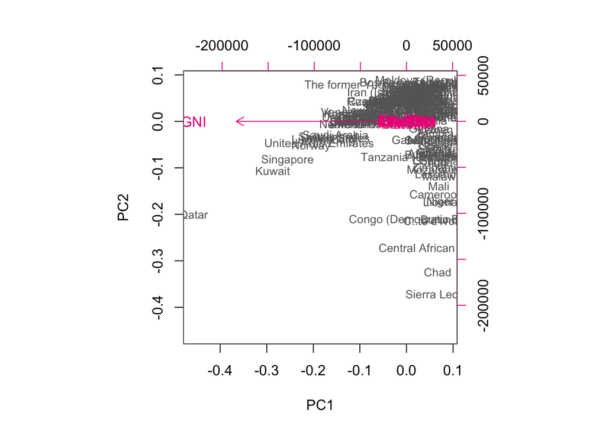

Figure 1. A mess due to non-scaled data

```r
# draw a biplot of the principal component representation and the original variables
biplot(pca_human, choices = 1:2, cex = c(0.8, 1) ,col = c("grey40", "deeppink2"))
```

Using the unscaled data does not bring out variance explained by the components. The plot shows that this is most likely due to GNI: it has vastly different scale when compared to other variables so the distance that other variables would create to the model does not matter.

Do the same with standardized data, then.

```r
# standardize the variables
human_std <- scale(human)
# perform principal component analysis (with the SVD method)
pca_human <- prcomp(human_std)

# print out summaries of the standardized variables and the model
summary(human_std)
```

```
##     Edu2.FM           Labo.FM           Edu.Exp           Life.Exp
##  Min.   :-2.8189   Min.   :-2.6247   Min.   :-2.7378   Min.   :-2.7188
##  1st Qu.:-0.5233   1st Qu.:-0.5484   1st Qu.:-0.6782   1st Qu.:-0.6425
##  Median : 0.3503   Median : 0.2316   Median : 0.1140   Median : 0.3056
##  Mean   : 0.0000   Mean   : 0.0000   Mean   : 0.0000   Mean   : 0.0000
##  3rd Qu.: 0.5958   3rd Qu.: 0.7350   3rd Qu.: 0.7126   3rd Qu.: 0.6717
##  Max.   : 2.6646   Max.   : 1.6632   Max.   : 2.4730   Max.   : 1.4218
##       GNI             Mat.Mor          Ado.Birth          Parli.F
##  Min.   :-0.9193   Min.   :-0.6992   Min.   :-1.1325   Min.   :-1.8203
##  1st Qu.:-0.7243   1st Qu.:-0.6496   1st Qu.:-0.8394   1st Qu.:-0.7409
##  Median :-0.3013   Median :-0.4726   Median :-0.3298   Median :-0.1403
##  Mean   : 0.0000   Mean   : 0.0000   Mean   : 0.0000   Mean   : 0.0000
##  3rd Qu.: 0.3712   3rd Qu.: 0.1932   3rd Qu.: 0.6030   3rd Qu.: 0.6127
##  Max.   : 5.6890   Max.   : 4.4899   Max.   : 3.8344   Max.   : 3.1850
```

```r
s <- summary(pca_human)
s
```

```
## Importance of components:
##                           PC1    PC2     PC3     PC4     PC5     PC6
## Standard deviation     2.0708 1.1397 0.87505 0.77886 0.66196 0.53631
## Proportion of Variance 0.5361 0.1624 0.09571 0.07583 0.05477 0.03595
## Cumulative Proportion  0.5361 0.6984 0.79413 0.86996 0.92473 0.96069
##                            PC7     PC8
## Standard deviation     0.45900 0.32224
## Proportion of Variance 0.02634 0.01298
## Cumulative Proportion  0.98702 1.00000
```

```r
pca_human
```

```
## Standard deviations:
## [1] 2.0708380 1.1397204 0.8750485 0.7788630 0.6619563 0.5363061 0.4589994
## [8] 0.3222406
##
## Rotation:
##                   PC1         PC2         PC3         PC4        PC5
## Edu2.FM   -0.35664370  0.03796058 -0.24223089  0.62678110 -0.5983585
## Labo.FM    0.05457785  0.72432726 -0.58428770  0.06199424  0.2625067
## Edu.Exp   -0.42766720  0.13940571 -0.07340270 -0.07020294  0.1659678
## Life.Exp  -0.44372240 -0.02530473  0.10991305 -0.05834819  0.1628935
## GNI       -0.35048295  0.05060876 -0.20168779 -0.72727675 -0.4950306
## Mat.Mor    0.43697098  0.14508727 -0.12522539 -0.25170614 -0.1800657
## Ado.Birth  0.41126010  0.07708468  0.01968243  0.04986763 -0.4672068
## Parli.F   -0.08438558  0.65136866  0.72506309  0.01396293 -0.1523699
##                   PC6         PC7         PC8
## Edu2.FM    0.17713316  0.05773644  0.16459453
## Labo.FM   -0.03500707 -0.22729927 -0.07304568
## Edu.Exp   -0.38606919  0.77962966 -0.05415984
## Life.Exp  -0.42242796 -0.43406432  0.62737008
## GNI        0.11120305 -0.13711838 -0.16961173
## Mat.Mor    0.17370039  0.35380306  0.72193946
## Ado.Birth -0.76056557 -0.06897064 -0.14335186
## Parli.F    0.13749772  0.00568387 -0.02306476
```

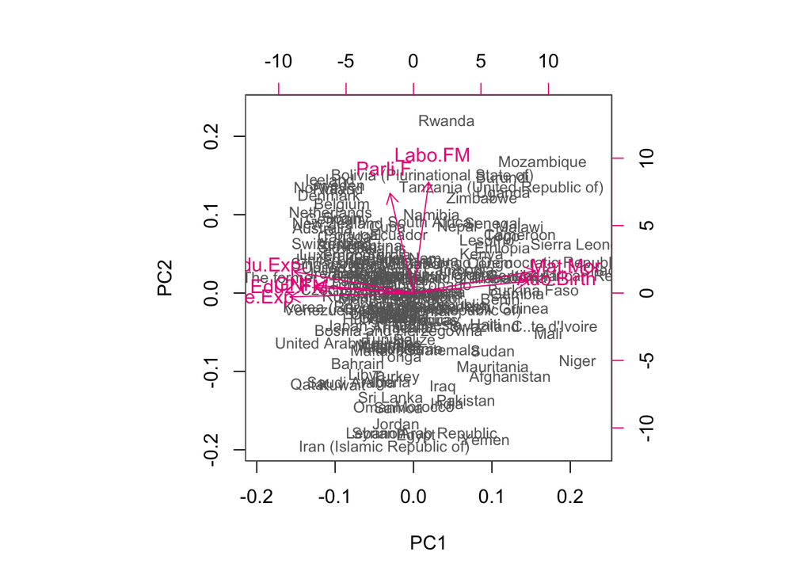

Figure 2. National wellbeing and female participation dimensions

```r
# draw a biplot of the principal component representation and the original variables
biplot(pca_human, choices = 1:2, cex = c(0.8, 1) ,col = c("grey40", "deeppink2"))
```

This is much better now. We can see that all the variables are now on the same scale. First dimension still explains most of the variance (around 54 percent), but not all of it. Ratio of females/males of the workforce is heavily loaded to component 2, as is the percentage of females in the parliament. Plot confirms this. However, Parli.F seems to pull slightly towards the countries with high GNI and overall higher life quality meters such as life expectancy, whilst the labour ratio pulls slightly towards qualities such as high maternal mortality.

## TeaTime-data and MCA

Now we will do Multiple Correspondence Analysis, which can be used to detect patterns or structure in the data. It can be also used to reduce data dimensions. We will use data that has answers to questionnaire related to tea consumption.

```r
library(FactoMineR)
#load the tea data
data("tea")
str(tea)
```

```
## 'data.frame':    300 obs. of  36 variables:
##  $ breakfast       : Factor w/ 2 levels "breakfast","Not.breakfast": 1 1 2 2 1 2 1 2 1 1 ...
##  $ tea.time        : Factor w/ 2 levels "Not.tea time",..: 1 1 2 1 1 1 2 2 2 1 ...
##  $ evening         : Factor w/ 2 levels "evening","Not.evening": 2 2 1 2 1 2 2 1 2 1 ...
##  $ lunch           : Factor w/ 2 levels "lunch","Not.lunch": 2 2 2 2 2 2 2 2 2 2 ...
##  $ dinner          : Factor w/ 2 levels "dinner","Not.dinner": 2 2 1 1 2 1 2 2 2 2 ...
##  $ always          : Factor w/ 2 levels "always","Not.always": 2 2 2 2 1 2 2 2 2 2 ...
##  $ home            : Factor w/ 2 levels "home","Not.home": 1 1 1 1 1 1 1 1 1 1 ...
##  $ work            : Factor w/ 2 levels "Not.work","work": 1 1 2 1 1 1 1 1 1 1 ...
##  $ tearoom         : Factor w/ 2 levels "Not.tearoom",..: 1 1 1 1 1 1 1 1 1 2 ...
##  $ friends         : Factor w/ 2 levels "friends","Not.friends": 2 2 1 2 2 2 1 2 2 2 ...
##  $ resto           : Factor w/ 2 levels "Not.resto","resto": 1 1 2 1 1 1 1 1 1 1 ...
##  $ pub             : Factor w/ 2 levels "Not.pub","pub": 1 1 1 1 1 1 1 1 1 1 ...
##  $ Tea             : Factor w/ 3 levels "black","Earl Grey",..: 1 1 2 2 2 2 2 1 2 1 ...
##  $ How             : Factor w/ 4 levels "alone","lemon",..: 1 3 1 1 1 1 1 3 3 1 ...
```

[output cut: 22 more lines]

I want to simplify the dataset a bit, so I will take 12 first variables of the dataset. This is due to these variables holding when and where -type of data, with one variable indicating if drinking tea is done with friends. It is interesting to see if this sort of spatio-temporal mixture of data with a hint of social factors leads to some revelations

```r
library(reshape2)

tea_sub <- tea[,1:12]
d <- gather(tea_sub)
```

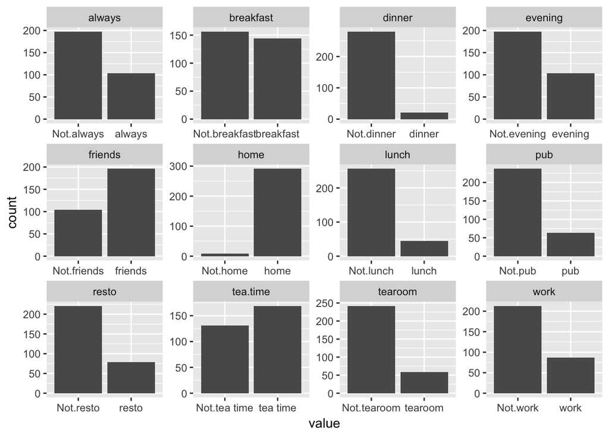

```r
ggplot(d,aes(value)) +
    facet_wrap("key",scales = "free") +
    geom_bar()
```

Most people do not enjoy tea during dinner, and tend to drink it home. Drinking tea at brakfast divides data fairly evenly. Lunch is not tea time for many. Tea is often enjoyed with friends, but not in a pub.

Let’s create the model.

```r
#create mca model
mca <- MCA(tea_sub, graph = FALSE)

# print statistics of the model
summary(mca)
```

```
##
## Call:
## MCA(X = tea_sub, graph = FALSE)
##
##
## Eigenvalues
##                        Dim.1   Dim.2   Dim.3   Dim.4   Dim.5   Dim.6
## Variance               0.170   0.110   0.099   0.090   0.088   0.080
## % of var.             17.038  11.006   9.935   9.027   8.833   7.963
## Cumulative % of var.  17.038  28.044  37.979  47.006  55.839  63.801
##                        Dim.7   Dim.8   Dim.9  Dim.10  Dim.11  Dim.12
## Variance               0.075   0.066   0.062   0.059   0.056   0.043
## % of var.              7.482   6.629   6.204   5.934   5.624   4.325
## Cumulative % of var.  71.284  77.913  84.117  90.051  95.675 100.000
##
## Individuals (the 10 first)
##                  Dim.1    ctr   cos2    Dim.2    ctr   cos2    Dim.3
## 1             | -0.571  0.638  0.571 | -0.346  0.363  0.210 | -0.032
## 2             | -0.571  0.638  0.571 | -0.346  0.363  0.210 | -0.032
## 3             |  0.134  0.035  0.009 |  0.641  1.243  0.206 | -0.220
## 4             | -0.900  1.583  0.488 |  0.394  0.470  0.094 |  0.046
## 5             | -0.290  0.164  0.104 | -0.040  0.005  0.002 |  0.179
## 6             | -0.900  1.583  0.488 |  0.394  0.470  0.094 |  0.046
## 7             | -0.122  0.029  0.036 | -0.389  0.458  0.364 | -0.202
## 8             | -0.265  0.137  0.111 |  0.060  0.011  0.006 | -0.302
## 9             | -0.358  0.251  0.243 | -0.527  0.840  0.525 | -0.174
## 10            | -0.130  0.033  0.017 | -0.129  0.051  0.016 | -0.139
##                  ctr   cos2
## 1              0.003  0.002 |
## 2              0.003  0.002 |
## 3              0.162  0.024 |
## 4              0.007  0.001 |
## 5              0.107  0.040 |
## 6              0.007  0.001 |
## 7              0.137  0.098 |
## 8              0.306  0.145 |
## 9              0.101  0.057 |
## 10             0.065  0.019 |
##
## Categories (the 10 first)
```

[output cut: 20 more lines]

```
## dinner          6.619 |   0.095   0.053   0.001   0.450 |
## Not.dinner     -6.619 |  -0.007   0.004   0.001  -0.450 |
##
## Categorical variables (eta2)
##                 Dim.1 Dim.2 Dim.3
## breakfast     | 0.020 0.522 0.009 |
## tea.time      | 0.273 0.127 0.071 |
## evening       | 0.126 0.179 0.104 |
## lunch         | 0.127 0.001 0.258 |
## dinner        | 0.118 0.147 0.001 |
## always        | 0.094 0.024 0.490 |
## home          | 0.001 0.154 0.010 |
## work          | 0.181 0.025 0.082 |
## tearoom       | 0.322 0.000 0.012 |
## friends       | 0.311 0.068 0.003 |
```

Dimension 1 and 2 seem to be separated by drinking tea during the dinner time the most according to the variables shown in summary. Drinking tea during dinner time is highly loaded to dim 2 as is not drinking tea at the breakfast. Plotting shows that drinking tea home or not is also important for this dimension. Dimension 1 is more cluttered. Drinking tea in tearooms and with friends is more loaded to this component according to eta2 value. Third dimension seems to be related to drinking tea always.

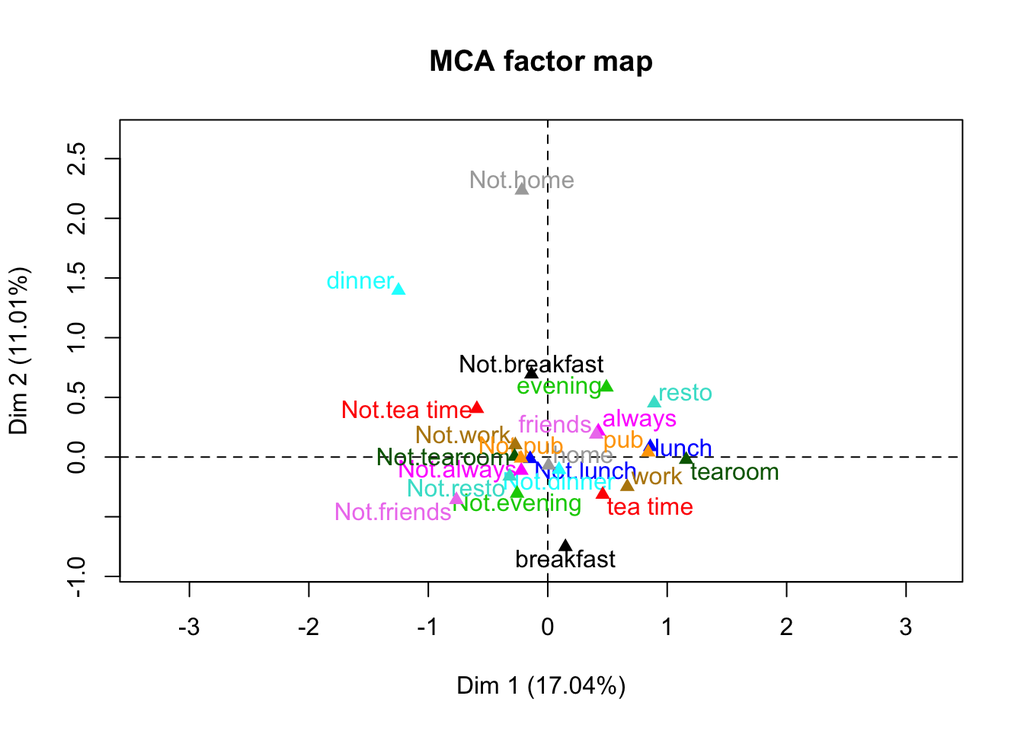

```r
plot(mca, invisible=c("ind"), habillage = "quali")
```

Inspired by Ville Harjunen (https://villehar.github.io/IODS-project/), I wanted to also try and draw plot that he used with his project. I removed arrows from the plot for clarity. Here also individuals are shown. It seems that there are people who prefer drinking tea only on dinners, and seldom at home. Dimension may represent also generally people who seldom drink tea in comparison to those who drink it everywhere, all the time, culminating to people who actually visit specialized tea houses.

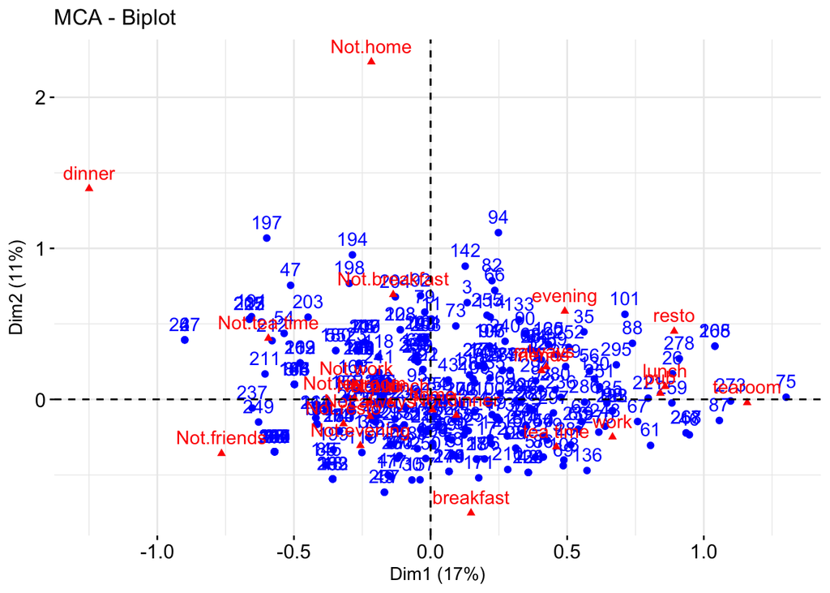

```r
library("devtools")
library("factoextra")

fviz_mca_biplot(mca, axes = c(1, 2), geom = c("point", "text"),
  label = "all")
```